# Seeing the (Random) Forest for the Trees

2020-08-31

One of my research studies utilizes a random forest algorithm to predict continuous biomechanical variables. Specifically, I used a Quantile Regression Forest (QRF) in R using the `caret` and `quantregForest` package. I will try to describe Random Forest algorithms in a sentence: They are a type of algorithm that aggregates a large number of predictions made by decision *trees* and produces a single prediction for the whole *forest*.

When I was assessing the accuracy of my QRF model, I wanted to visualize the variability in the individual tree predictions alongside the aggregated prediction (seeing the forest for the trees, so to speek). After looking around online, I couldn’t find any examples of someone doing this, so I thought I’d do a quick write-up on my process. Maybe it’s beneficial to someone wanting to better visualize what a random forest algorithm is actually doing inside the “black box” of this machine learning algorithm.

I’ll use the `mtcars` dataset to try and predict a car’s MPG:

```r
library(tidyr)
library(caret)
library(quantregForest)
library(ggplot2)
library(ggridges)

# head(mtcars)
qrf<- train(mpg ~ cyl + disp + hp + drat + wt, data = mtcars, method = 'qrf')  # train QRF model
```

We can then make predictions using `predict()`. However, this function will not provide predictions for each QRF tree (500 of them in this case) by default. We need to change the class of the `finalModel` to only ‘randomForest’. This provides predictions for the forest (`aggregate`) and the trees (`individual`):

```r
n_cars = 8
class(qrf$finalModel)
```

```
## [1] "quantregForest" "randomForest"
```

```r
class(qrf$finalModel) <- 'randomForest'
pred <- predict(qrf$finalModel, mtcars[1:n_cars,], predict.all = T)
str(pred)
```

```
## List of 2
##  $ aggregate : Named num [1:8] 20.8 20.8 24.2 20 17.4 ...
##   ..- attr(*, "names")= chr [1:8] "Mazda RX4" "Mazda RX4 Wag" "Datsun 710" "Hornet 4 Drive" ...
##  $ individual: num [1:8, 1:500] 20.5 20.5 27 20.5 17.9 ...
##   ..- attr(*, "dimnames")=List of 2
##   .. ..$ : chr [1:8] "Mazda RX4" "Mazda RX4 Wag" "Datsun 710" "Hornet 4 Drive" ...
##   .. ..$ : NULL
```

I chose to visualize the tree predictions with ridgeplots in a predicts vs observed plot. The format of `pred` isn’t ggplot friendly, so we need to do some reshaping with `tidyr`, `aggregate`, and `merge` before plotting:

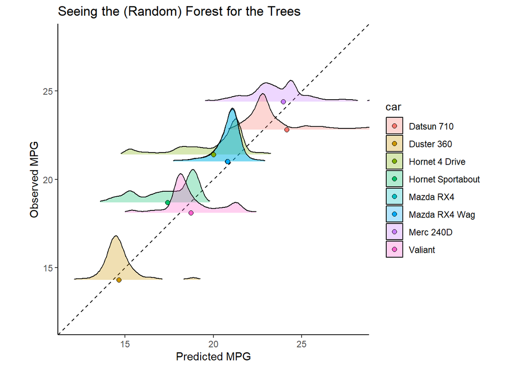

```r
# reshape individual tree predictions for ggplot
obs <- mtcars$mpg[1:n_cars]
car <- row.names(mtcars)[1:n_cars]
tree_pred <- as.data.frame(pred$individual)
colnames(tree_pred) <- 1:500
tree_pred$obs <- obs
tree_pred$car <- car
tree_pred_long <- gather(tree_pred, tree, pred, 1:500)

# reshape aggregate predictions for ggplot
agg <- aggregate(pred ~ obs + car, data = tree_pred_long, FUN = mean)  # same as pred$aggregate values
colnames(agg) <- c('obs', 'car', 'mean_pred')
pred_obs <- data.frame(pred = pred$aggregate, obs = obs)
pred_obs <- merge(pred_obs, agg, by = 'obs')

# plot distribution of tree predictions and aggregate prediction of final QRF model
ggplot(tree_pred_long) +
  geom_abline(slope = 1, intercept = 0, lty = 2)+  # line of identity
  geom_density_ridges(aes(x = pred, y = obs, group = car, fill = car),
                      alpha = 0.3, color = 'black', rel_min_height = 0.02, size = 0.5)+
  geom_point(data = pred_obs, aes(x = pred, y = obs, fill = car), pch = 21, size = 2)+
  theme_classic()+
  ggtitle('Seeing the (Random) Forest for the Trees')+
  coord_fixed(xlim = c(12,28), ylim = c(12,28))+
  scale_y_continuous('Observed MPG', breaks = seq(15,30,5))+
  scale_x_continuous('Predicted MPG', breaks = seq(15,30,5))
```

### Conclusion

The Ridgeplots don’t adhere to the units of the y axis, but they show us the relative distribution of the individual predictions that make up the quantile regression forest. It’s kinda neat to see how the tree predictions compare to the final aggregated prediction!